# Assignment 1

Songying Chen 202310780

Oct. 11th 2023

This document contains answers of formative assignment 1. The following script is my answer.

#Setup

# Exercise 1

My forked version of the assignment template repository can be found at https://github.com/WildPigen/472_assignment_template

# Exercise 2

##This is the coding of exercise 2

```
##         Jan    Feb    Mar    Apr    May    Jun    Jul    Aug    Sep    Oct
## 1959 315.42 316.31 316.50 317.56 318.13 318.00 316.39 314.65 313.68 313.18
## 1960 316.27 316.81 317.42 318.87 319.87 319.43 318.01 315.74 314.00 313.68
## 1961 316.73 317.54 318.38 319.31 320.42 319.61 318.42 316.63 314.83 315.16
## 1962 317.78 318.40 319.53 320.42 320.85 320.45 319.45 317.25 316.11 315.27
## 1963 318.58 318.92 319.70 321.22 322.08 321.31 319.58 317.61 316.05 315.83
## 1964 319.41 320.07 320.74 321.40 322.06 321.73 320.27 318.54 316.54 316.71
## 1965 319.27 320.28 320.73 321.97 322.00 321.71 321.05 318.71 317.66 317.14
## 1966 320.46 321.43 322.23 323.54 323.91 323.59 322.24 320.20 318.48 317.94
## 1967 322.17 322.34 322.88 324.25 324.83 323.93 322.38 320.76 319.10 319.24
## 1968 322.40 322.99 323.73 324.86 325.40 325.20 323.98 321.95 320.18 320.09
## 1969 323.83 324.26 325.47 326.50 327.21 326.54 325.72 323.50 322.22 321.62
## 1970 324.89 325.82 326.77 327.97 327.91 327.50 326.18 324.53 322.93 322.90
## 1971 326.01 326.51 327.01 327.62 328.76 328.40 327.20 325.27 323.20 323.40
## 1972 326.60 327.47 327.58 329.56 329.90 328.92 327.88 326.16 324.68 325.04
```

[output cut: 65 more lines]

```
## [1] 315.42 316.31 316.50 317.56 318.13 318.00
```

*The first few rows of the dataset co2 is not tidy because this data is a time-series matrix instead of a dataset. And even if we see it as a dataset, the structure of co2 is untidy. We can simply convert the data into three column “Year”,“Month”, and “Value”.

*The following code shows how I manage to convert the untidy matrix data into a tidy dataset one. The thing I would need to do is to first convert matrix into dataset and then pivot_longer.

```
## # A tibble: 6 × 3
##    year Month   COE
##   <int> <chr> <dbl>
## 1  1959 1      315.
## 2  1959 2      316.
## 3  1959 3      316.
## 4  1959 4      318.
## 5  1959 5      318.
## 6  1959 6      318
```

*In short, the above code shows how the data co2, shown in time-series matrix and untidy, is convert into a tidy dataset. To compare the difference of data before and after, here list a few characteristics of the two data form.

For the former data, co2, it has the following traits:

1.Column headers are values, not variable names

2.Multiple variables are stored in one column, namely the Month and CO2 Emission

3.Variables are stored in both rows and columns

For the later data, co2_long, it has the following traits:

1.Each variable forms a column

2.Each observation forms a row

3.Each type of observational unit forms a table

*Therefore, I try to convert the data to make every row shows one observation and make the two date information “month”, and “year” clear by pivot longer.

references: [1] Wickham, Hadley. 2014. Tidy Data. Journal of Statistical Software; Vol 59; Issue 10. Retrieved from https://www.jstatsoft.org/article/view/v059i10

# Exercise 3

*below shows the results and code of exercise 3

```r
#load the data of UCB admissions in R and view the data
data("UCBAdmissions")
view(UCBAdmissions)

#convert the data into a dataset
ucb <-as.data.frame(UCBAdmissions)
head(ucb)
```

```
##      Admit Gender Dept Freq
## 1 Admitted   Male    A  512
## 2 Rejected   Male    A  313
## 3 Admitted Female    A   89
## 4 Rejected Female    A   19
## 5 Admitted   Male    B  353
## 6 Rejected   Male    B  207
```

```r
#try to figure out different admission rates in different genders in the same department
ucb_ratio_bygender <- ucb %>%
  group_by(Gender,Dept) %>% #group the data by Gender and Department so that the following analysis is valid
  mutate(applicant = sum(Freq)) %>% #add a column to calculate all the applicants in the same Dept and Gender
  filter(Admit == "Admitted") %>% #filter the ones who get admitted to calculate the admission rate
  summarise(Ratio = Freq / applicant) #summarise the info to see admission rates in different genders in the same department
head(ucb_ratio_bygender)
```

```
## # A tibble: 6 × 3
## # Groups:   Gender [1]
##   Gender Dept   Ratio
##   <fct>  <fct>  <dbl>
## 1 Male   A     0.621
## 2 Male   B     0.630
## 3 Male   C     0.369
## 4 Male   D     0.331
## 5 Male   E     0.277
## 6 Male   F     0.0590
```

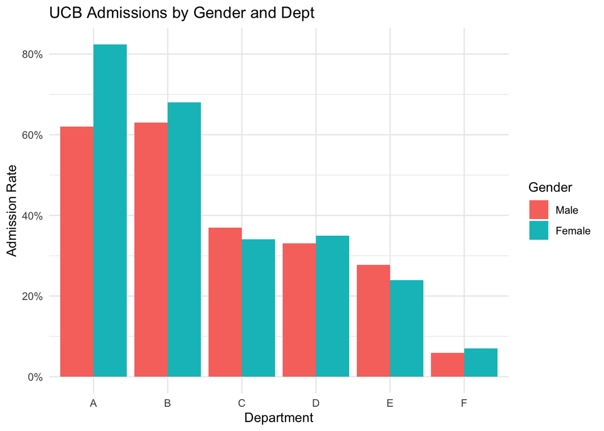

```r
# Create a bar chart for admission rates
gender_plot <- ggplot(ucb_ratio_bygender, #draw a bar chart by ggplot2
                      aes(x = Dept, y = Ratio, fill = Gender)) +#set the x and y data and fill the data by Gender
  geom_bar(stat = "identity", position = "dodge") + #set the why I would like to plot the bar graph
  scale_y_continuous(labels = scales :: percent) + #set the y axis into a percentage format
  labs(title = "UCB Admissions by Gender and Dept", #set the title and labels of x and y
       x = "Department", y = "Admission Rate") +
  theme_minimal()
gender_plot #plot the graph
```

In the transformed dataset, I try to calculate the admission rate by gender and department and turned the frequency numbers into a much more informative ratio. Therefore, in the summarized dataset, the data is presented in a way that is much easy for the reader to capture whether the admission rates of different gender type are significantly different based departments. Also, I have plot a graph to make the data more visualized and easy to compare.

# Appendix: All code in this assignment

```r
knitr::opts_chunk$set(echo = FALSE)

#set the environment and get all the packages that may be useful
library(tidyverse)
library(ggplot2)
library(lubridate)
library(scales)
data("co2") #get data
force(co2) #display the data
head(co2) #show the first few rows of data
#convert time-series matrix to dataset
df <- as.data.frame(t(matrix(co2, 12))) #convert the matrix into a dataset
df <- df %>%
  mutate(c(1959:1997)) #add the value of variable "year"
colnames(df) <- c(1:12, "year") #rename the columns into more informative ones

#pivot long
co2_long <- df %>%
  pivot_longer(cols = colnames(df)[1:12],
                        names_to = "Month", values_to = "COE") #pivot the dataset longer to make it tidy. I set the variable from column[1:12] and name it to "Month", and match the values as "COE"
head(co2_long) #show the first few rows of the longer dataset

#load the data of UCB admissions in R and view the data
data("UCBAdmissions")
view(UCBAdmissions)

#convert the data into a dataset
ucb <-as.data.frame(UCBAdmissions)
head(ucb)

#try to figure out different admission rates in different genders in the same department
ucb_ratio_bygender <- ucb %>%
  group_by(Gender,Dept) %>% #group the data by Gender and Department so that the following analysis is valid
  mutate(applicant = sum(Freq)) %>% #add a column to calculate all the applicants in the same Dept and Gender
  filter(Admit == "Admitted") %>% #filter the ones who get admitted to calculate the admission rate
  summarise(Ratio = Freq / applicant) #summarise the info to see admission rates in different genders in the same department

head(ucb_ratio_bygender)

# Create a bar chart for admission rates
gender_plot <- ggplot(ucb_ratio_bygender, #draw a bar chart by ggplot2
                      aes(x = Dept, y = Ratio, fill = Gender)) +#set the x and y data and fill the data by Gender
  geom_bar(stat = "identity", position = "dodge") + #set the why I would like to plot the bar graph
  scale_y_continuous(labels = scales :: percent) + #set the y axis into a percentage format
  labs(title = "UCB Admissions by Gender and Dept", #set the title and labels of x and y
       x = "Department", y = "Admission Rate") +
  theme_minimal()
gender_plot #plot the graph
# this chunk generates the complete code appendix.
# eval=FALSE tells R not to run (``evaluate'') the code here (it was already run before).
```